# Phase Space Reconstruction of Core Body Temperature

One concept in the study of complex dynamical systems is the idea that we do not necessarily need to measure every single interacting variable to understand the system as a whole. According to Takens' (1981) Delay Embedding Theorem, the time series of a single variable inherently contains information about the other unmeasured variables within that same system. Because these variables dynamically couple and interact over time, taking delayed copies (lags) of our single measured variable allows us to create an isomorphic depiction of the entire system's underlying dynamics.

The goal of Phase Space Reconstruction (PSR) is to reconstruct these multi-dimensional system dynamics from a single time series. In this tutorial, we will walk through the steps of PSR using empirical sensor data, specifically focusing on Core Body Temperature (CBT). We will systematically determine the appropriate time delay (τ) and embedding dimension (M), reconstruct the phase space, and finally introduce a way to visualize high-dimensional attractors beyond standard 3D plots.

For this analysis, we are using a single continuous time series of Core Body Temperature (temperature_C) collected from the sensors of one cow (C01). Body temperature is an example of a complex system, governed by interacting circadian, metabolic, and environmental sub-systems.

```r
#install.packages("tseriesChaos")
#install.packages("nonlinearTseries")
#install.packages("plot3D")
#install.packages("rgl")
#install.packages("GGally")
library(readr)
library(tseriesChaos)
library(nonlinearTseries)
library(plot3D)
library(rgl)
library(MASS)
library(GGally)
library(ggplot2)
library(dplyr)

# load the data
cbt_df <- read_csv("data/sensor_data/main_data/cbt/C01.csv")
temperature_vector <- cbt_df$temperature_C
```

## Step 1: Determining the Time Delay ($\tau$)

Our first objective is to determine an appropriate time delay, $\tau$. These delayed values will serve as the coordinates for our reconstructed phase space. The goal is to find a delay that separates the trajectories as much as possible while remaining reasonable. We typically evaluate this using two methods: the first zero-crossing of the Auto-Correlation Function (ACF) or the first local minimum of the Average Mutual Information (AMI) function.

```
[1] "First zero-crossing of the ACF: 70"
```

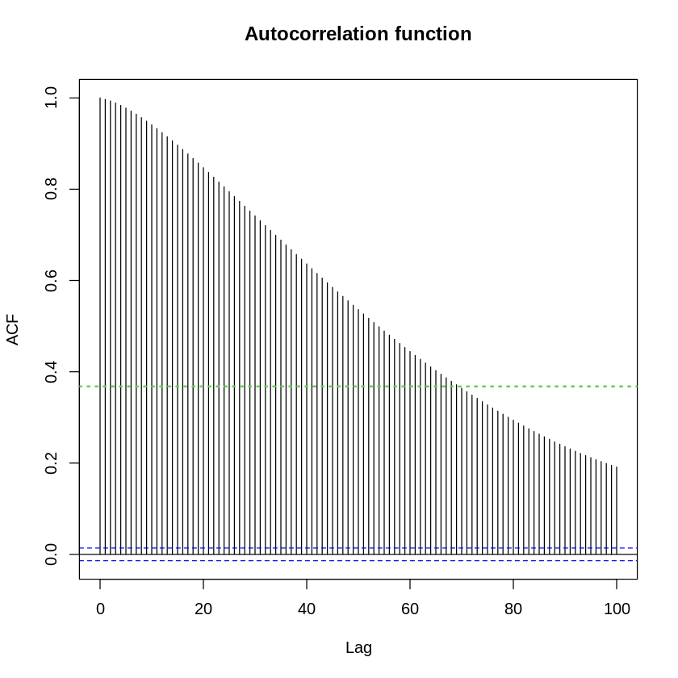

```
[1] "First local minimum of the AMI function: 12"
```

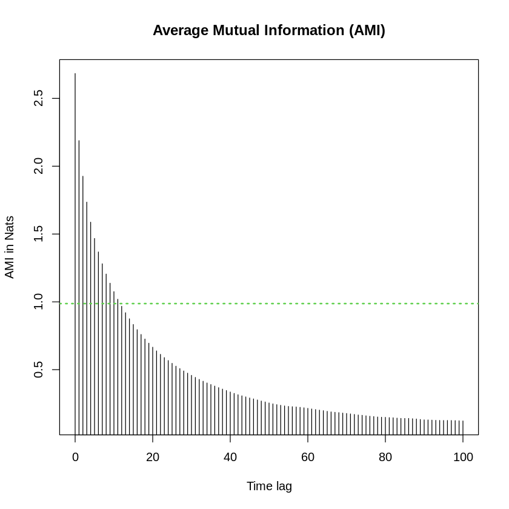

```r
tau.acf <- timeLag(temperature_vector, technique = "acf", lag.max = 100, do.plot = T)
print(paste0("First zero-crossing of the ACF: ", tau.acf))
tau.ami <- timeLag(temperature_vector, technique ="ami", lag.max = 100, do.plot = T)
print(paste0("First local minimum of the AMI function: ", tau.ami))
```

The ACF suggests a time delay of 70, while the AMI suggests a much shorter delay of 12. Because the ACF only captures linear relationships and AMI captures both linear and nonlinear dependencies, it is often safer to rely on AMI when dealing with complex physiological data. Therefore, we will proceed with the nonlinear estimation of $\tau = 12$.

## Step 2: Determining the Embedding Dimension ($M$)

Next, we need to figure out how many dimensions (time-delayed copies) are required to properly "unfold" the attractor so that trajectories do not falsely overlap. A common approach is the False Nearest Neighbors (FNN) algorithm (Kennel, Brown, & Abarbanel, 1992).

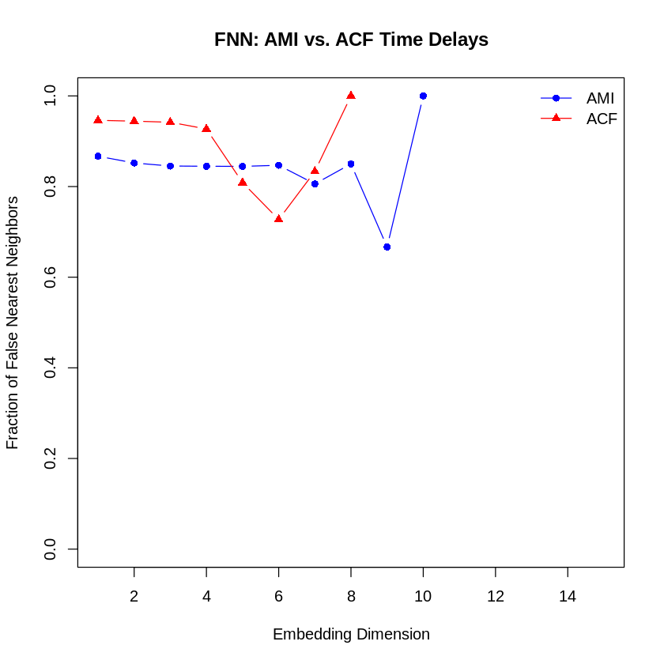

```r
# calculate FNN with AMI
fnn.out.ami = false.nearest(temperature_vector, m = 15, d = tau.ami, t = 50, eps = sd(temperature_vector)/10)

# calculate FNN with ACF - just for comparison, but we already chose to proceed with AMI
fnn.out.acf = false.nearest(temperature_vector, m = 15, d = tau.acf, t = 50, eps = sd(temperature_vector)/10)

# plot the AMI values first
# extracting the first row [1, ] which contains the fraction of FNN
plot(fnn.out.ami[1, ], type = "b", col = "blue", pch = 16,
     ylim = c(0, max(fnn.out.ami[1, ], fnn.out.acf[1, ], na.rm = TRUE)),
     xlab = "Embedding Dimension",
     ylab = "Fraction of False Nearest Neighbors",
     main = "FNN: AMI vs. ACF Time Delays")

# add the ACF values to the existing plot
lines(fnn.out.acf[1, ], type = "b", col = "red", pch = 17)

# add a legend
legend("topright",
       legend = c("AMI", "ACF"),
       col = c("blue", "red"),
       pch = c(16, 17),
       lty = 1,
       bty = "n")
```

When running the FNN algorithm, the percentage of false nearest neighbors failed to smoothly drop to zero as we increased the dimensions. FNN can be highly sensitive to noise in empirical datasets. To overcome this limitation, we turn to Cao's (1997) method, which provides a more robust metric ($E1(d)$) for determining the minimum embedding dimension by looking for the point where the metric approaches 1 and stops changing.

```
[1] "Embedding dimension required according to Cao's method: 3"
```

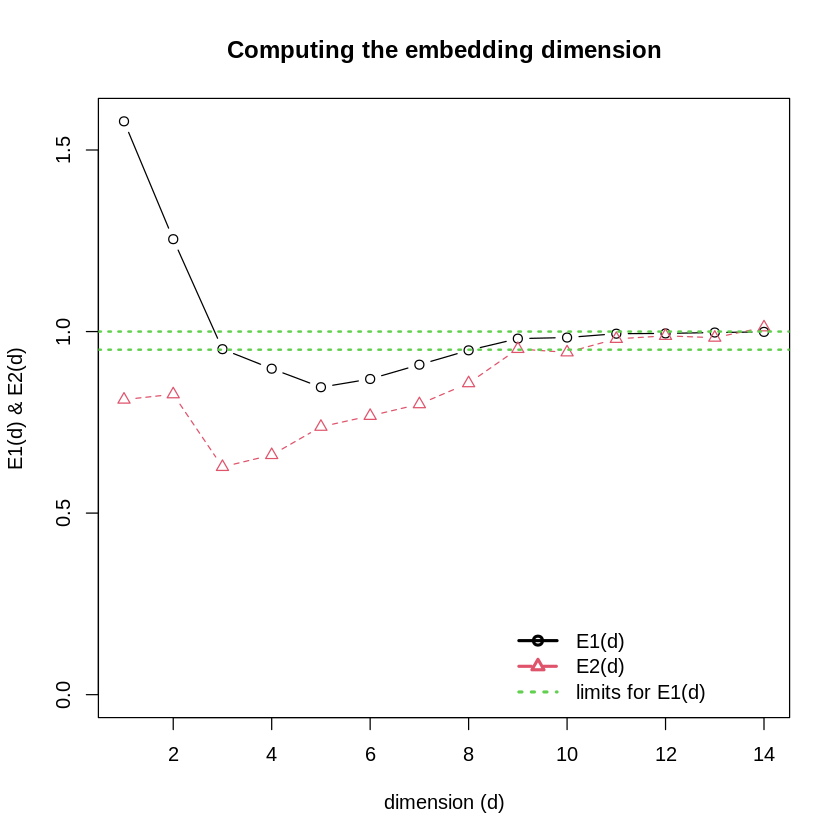

```r
# FNN couldn't deal with too much noise - so trying Cao's method
emb.dim = estimateEmbeddingDim(temperature_vector, time.lag = tau.ami, max.embedding.dim = 15)
print(paste0("Embedding dimension required according to Cao's method: ", emb.dim))
```

Based on the results from Cao's algorithm, the minimum embedding dimension is estimated to be 3, with 9 emerging as an alternative. As shown in the plot, the $E1(d)$ metric approaches 1 and its rate of change plateaus considerably at $M = 3$, an asymptote that becomes even more strictly defined by $M = 9$. We initially proceed with $M = 3$ to construct and evaluate a standard phase space reconstruction, employing Takens' delay coordinate embedding alongside conventional 2D and 3D spatial projections (using the plot3D and rgl packages). Subsequently, we adopt the higher-dimensional embedding ($M = 9$) to showcase a parallel coordinates approach for visualization.

## Step 3: Phase Space Reconstruction

### Standard Visualization

With our parameters set ($\tau = 12$, $M = 3$), we can now build the Takens' embedding matrix and visualize the system's phase space topology.

```r
# proceed with 3 dimensions - build time delayed embedding
cbt.ps <- buildTakens(temperature_vector,emb.dim,tau.ami)
head(cbt.ps, n=12)
```

A matrix: 12 × 3 of type dbl

| 38.35 | 38.41 | 38.41 |
| --- | --- | --- |
| 38.35 | 38.41 | 38.44 |
| 38.35 | 38.44 | 38.44 |
| 38.35 | 38.44 | 38.44 |
| 38.38 | 38.44 | 38.44 |
| 38.38 | 38.44 | 38.44 |
| 38.38 | 38.41 | 38.44 |
| 38.38 | 38.41 | 38.44 |
| 38.38 | 38.41 | 38.44 |
| 38.41 | 38.41 | 38.44 |
| 38.41 | 38.41 | 38.41 |
| 38.41 | 38.41 | 38.41 |

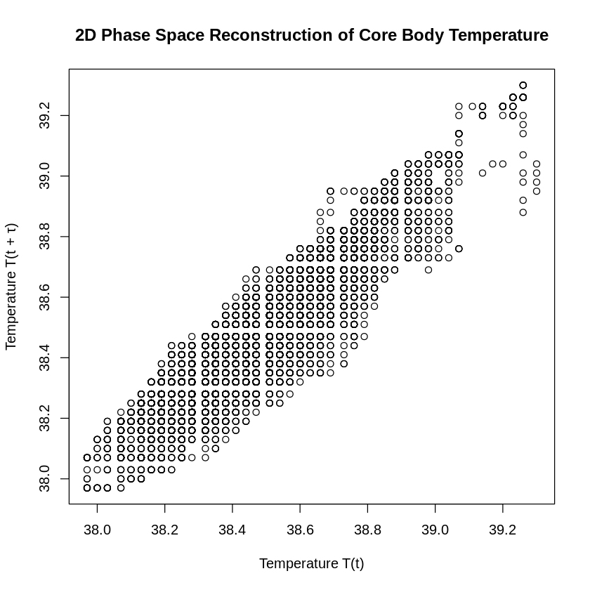

```r
# plot 2D
plot(cbt.ps,
     main = "2D Phase Space Reconstruction of Core Body Temperature",
     xlab = "Temperature T(t)",
     ylab = "Temperature T(t + \u03c4)") # \u03c4 is the R code to print the Greek letter tau!
```

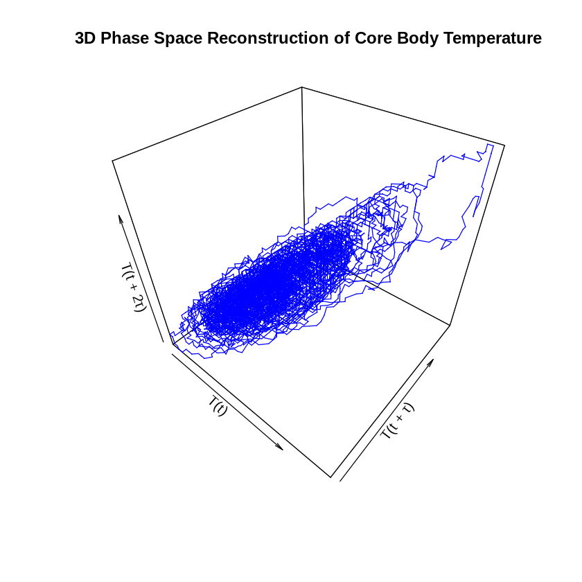

```r
# plot with all dimensions - 3D
lines3D(cbt.ps[,1], cbt.ps[,2], cbt.ps[,3],
        t = "l", col = "blue", asp = 1,
        main = "3D Phase Space Reconstruction of Core Body Temperature",
        xlab = "T(t)",
        ylab = "T(t + \u03c4)",
        zlab = "T(t + 2\u03c4)")
```

```r
# 3D interactive plot (note: works in R Studio, not in Google Colab)
plot3d(cbt.ps[,1],cbt.ps[,2],cbt.ps[,3], t="l", col="blue", size=.5)

plot3d(cbt.ps[,1], cbt.ps[,2], cbt.ps[,3],
       t = "l", col = "blue", size = 0.5,
       xlab = "T(t)",
       ylab = "T(t + \u03c4)",
       zlab = "T(t + 2\u03c4)")
# Add the title using title3d
title3d(main = "Interactive 3D Phase Space Reconstruction")
```

The standard 2D and 3D plots reveal that the core body temperature system occupies a dense, bounded region within the state space. Rather than forming a distinct geometric shape (like a circular limit cycle or a butterfly attractor), the trajectories form a packed, elongated cluster stretched along the diagonal. This "tube-like" structure indicates a strong persistence and high correlation in the temperature states over time; that is, the temperature generally changes gradually relative to the delay. While these plots successfully map the outer boundaries of the system's normal behavior, the density and overlapping of the trajectories make it difficult to discern any finer internal structures or distinct cyclical patterns. Furthermore, standard spatial visualizations are limited to three dimensions, leaving potential higher-dimensional dynamics completely hidden.

### Visualizing High-Dimensional Phase Space

Given that the standard 3D plot exposed little beyond the bounded and gradual nature of the data (both properties inherent to cows' body temperature) we opted to explore the higher embedding dimension of $M = 9$ previously indicated by Cao's method.

However, visualizing systems with more than three dimensions is challenging. To overcome this, we implemented a Parallel Coordinates plot using the GGally::ggparcoord package (Schloerke et al., 2025). By rounding the temperature values to group similar paths (sequences of temperatures) and then counting the frequency of specific paths, we can effectively map the "density" and "flow" of the phase space across all nine dimensions simultaneously.

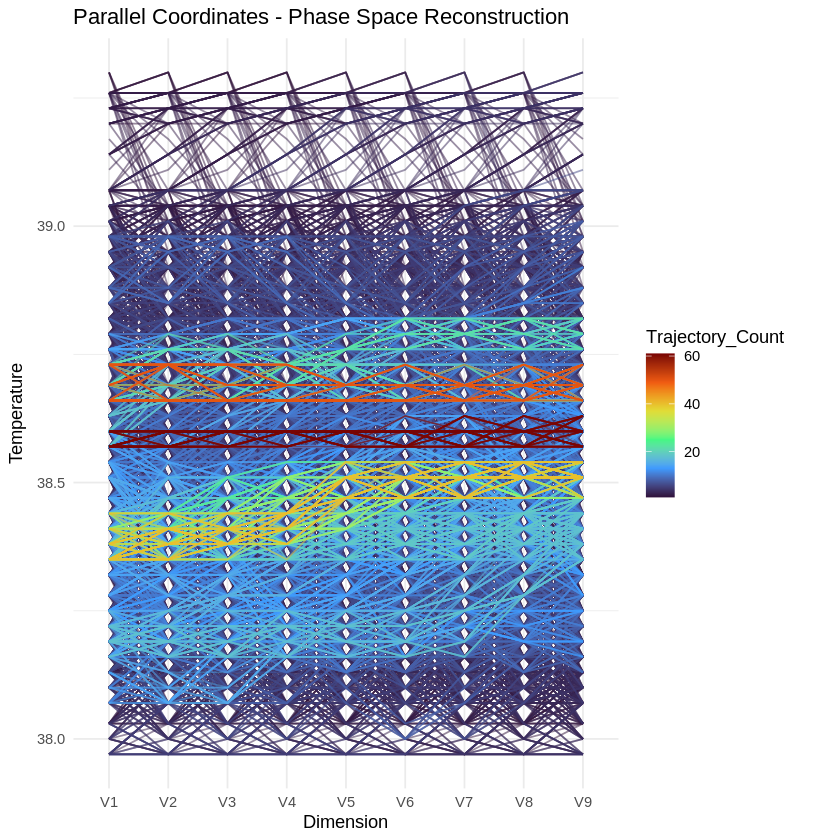

```r
# make 9D dataframe
cbt_9d.ps <- buildTakens(temperature_vector,9,tau.ami)
df_9d <- as.data.frame(cbt_9d.ps)
df_9d <- df_9d %>%
  mutate(across(1:9, ~ round(., 1), .names = "round_{.col}")) %>%
  group_by(across(starts_with("round_"))) %>%
  mutate(Trajectory_Count = n()) %>%
  ungroup() %>%
  dplyr::select(-starts_with("round_")) %>%
  arrange(Trajectory_Count)

# plot 9D - parallel coordinates plot
ggparcoord(df_9d,
           columns = 1:9,
           groupColumn = "Trajectory_Count",
           alphaLines = 0.5,
           scale = "globalminmax") +
  scale_color_viridis_c(option = "turbo") +
  labs(title = "Parallel Coordinates - Phase Space Reconstruction", x = "Dimension", y = "Temperature") +
  theme_minimal()
```

The resulting parallel coordinates plot offers a flattened perspective of the 9D phase space. In this visualization, the x-axis represents our sequential time-delayed dimensions ($V_1$ through $V_9$, corresponding to $t$, $t+\tau$, $t+2\tau$, etc.), and the y-axis maps the core body temperature. Each continuous line in this plot represents a single coordinate in the 9D phase space, effectively capturing a specific sequence of nine time-delayed temperatures. The lines are color-coded by Trajectory Count, allowing us to see the most frequently traveled "orbits" (reds/yellows) versus fleeting or noisy fluctuations (blues). This effectively flattens high-dimensional attractor dynamics into a readable 2D format, preserving both temporal sequence and state-space density.

Let us discuss some strengths and weaknesses of this plotting method. Firstly, the strengths and its implications w.r.t. the data:

- The most significant advantage of this method is that it allows us to visualize an arbitrary number of dimensions simultaneously. We are no longer restricted to just 2 or 3 dimensions.
- The color coding acts as a density indicator. The dark red and orange bands (particularly visible around the 38.6°C - 38.8°C range) represent highly frequented trajectories. This highlights the "core" of the attractor, i.e. the most stable and recurrent states of the core body temperature system.
- The dark blue lines represent rare trajectories. By visually pushing these low-frequency paths to the background, we can easily distinguish between the system's stable, deterministic flow and random stochastic fluctuations or anomalies. This helps separate the signal from noise.

Secondly, the limitations:

- As with many parallel coordinate plots handling large datasets, overplotting is a major issue. While the alpha blending and color scales help, the sheer volume of crossing lines makes it impossible to trace individual, low-frequency trajectories from $V_1$ to $V_9$.
- Standard 2D and 3D phase space plots (like the Lorenz butterfly) are excellent for showing the physical "shape," folds, and geometric limits of an attractor. Parallel coordinates obscure this geometry. We can see where the data clusters sequentially, but we lose the intuitive visual representation of how the system orbits and loops in space.
- In this plot, the axes are naturally ordered by sequential time delays, which makes logical sense. However, relationships between non-adjacent dimensions (e.g., $V_1$ and $V_8$) are much harder to interpret visually than relationships between adjacent ones. This hinders our ability to visually interpret the relationship between the current temperature and its more distant lags.

# Reflection and Limitations

Phase Space Reconstruction is a useful tool for uncovering the hidden architecture of complex systems from a single time series. However, applying Takens' theorem to empirical physiological data, such as the core body temperature of a cow, does not always yield the visually distinct, textbook topologies often associated with nonlinear dynamics.

As our initial 2D and 3D visualizations demonstrated, the system primarily exhibited a dense, "tube-like" cluster. While this successfully reflected the bounded, and gradual nature of cows' thermoregulation, it obscured any finer internal structures. This spatial limitation is exactly what necessitated our next approach: extending the embedding to $M = 9$ and employing a parallel coordinates plot to visualize the high-dimensional density and core flow of the attractor.

This analysis also highlighted several practical challenges and limitations inherent to PSR. Most notably, standard parameter estimation algorithms are sensitive to empirical noise, as evidenced by the FNN algorithm failing to drop smoothly, requiring us to pivot to Cao's more robust metric. Furthermore, the methodology involves a degree of subjectivity and justifications based on our expectations of the system. For example, when choosing the AMI over the ACF, or estimating where a metric plateaus. However, we want to note that despite these hurdles and the visual constraints of standard 3D plotting, properly embedding the time series remains a necessary first step for later analysis using more advanced methods such as such as Recurrence Quantification Analysis (RQA) and Empirical Dynamic Modeling (EDM).

### References

F. Takens (1981). Detecting strange attractors in turbulence. In D. A. Rand and L.-S. Young (ed.). Dynamical Systems and Turbulence, Lecture Notes in Mathematics, vol. 898. Springer-Verlag. pp. 366–381.

Kennel, M. B., Brown, R., & Abarbanel, H. D. (1992). Determining embedding dimension for phase-space reconstruction using a geometrical construction. Physical review. A, Atomic, molecular, and optical physics, 45(6), 3403–3411. https://doi.org/10.1103/physreva.45.3403

Cao, L. (1997). Practical method for determining the minimum embedding dimension of a scalar time series. Physica D: Nonlinear Phenomena, 110, 43-50.

Schloerke B, Cook D, Larmarange J, Briatte F, Marbach M, Thoen E, Elberg A, Crowley J (2025). GGally: Extension to 'ggplot2'. R package version 2.4.0, https://ggobi.github.io/ggally/.